# Investigate no-show appointments

- Introduction
- Data Wrangling
- Exploratory Data Analysis
- Conclusions

## Introduction

In this report we analyse the *No-Show Appointments* dataset. The dataset contains information on approximately 110000 mediacal appointments in Brazil and is focused on the question of whether or not patients showed up for their appointment.

The dataset was downloaded from [this location](https://d17h27t6h515a5.cloudfront.net/topher/2017/October/59dd2e9a_noshowappointments-kagglev2-may-2016/noshowappointments-kagglev2-may-2016.csv&sa=D&ust=1532469042118000)

**With the analyses in this report I want to find out how age and waiting time influence the no-show rate:**

1. Age related influence
   - Does the patient's age have an influence on the now-show rate?
2. Waiting time
   - Does the no-show rate depend on the waiting time, i.e. the number of days between the appointment and the day the appointment was scheduled?
3. SMS
   - For some appointments, SMS are sent. Do the SMS reduce the no-show rate?
4. Combined effect of SMS and waiting time

```python
import numpy as np
import pandas as pd
%matplotlib inline
%config InlineBackend.figure_format = 'retina'
import matplotlib.pyplot as plt
import seaborn as sns
```

## Data Wrangling

### General Properties

The infomation contained in the dataset are:

| Column | Description |
| --- | --- |
| PatientId | unique identifier for a person |
| AppointmentID | unique identifier for an appointment |
| Gender | the person's gender |
| ScheduledDay | the date when the person set up the appointment |
| AppointmentDay | the date of the appointment |
| Age | the person's age |
| Neighbourhood | location of the hostipal |
| Scholarship | indicated whether the person is enrolled in the Brasilian welfare program Bolsa Familia |
| Hipertension | whether the person suffers from hipertension |
| Diabetes | whether the person suffers from diabetes |
| Alcoholism | whether the person suffers from alcoholism |
| Handcap | the number of handicaps of this person |
| SMS_received | whether the person received an SMS to remind her of the appointment |
| No-show | whether the person showed up for the appointment. *Yes* means that the person was a no-show, *No* means that the person showed up for the appointment |

```python
# loading and visualising the data in raw format;
# show first 5 lines in order to identify format, separator used

fname = "noshowappointments-kagglev2-may-2016.csv"

with open(fname, encoding="utf-8") as fp:
    for i in range(5):
        print(fp.readline().strip())
```

```
PatientId,AppointmentID,Gender,ScheduledDay,AppointmentDay,Age,Neighbourhood,Scholarship,Hipertension,Diabetes,Alcoholism,Handcap,SMS_received,No-show
29872499824296,5642903,F,2016-04-29T18:38:08Z,2016-04-29T00:00:00Z,62,JARDIM DA PENHA,0,1,0,0,0,0,No
558997776694438,5642503,M,2016-04-29T16:08:27Z,2016-04-29T00:00:00Z,56,JARDIM DA PENHA,0,0,0,0,0,0,No
4262962299951,5642549,F,2016-04-29T16:19:04Z,2016-04-29T00:00:00Z,62,MATA DA PRAIA,0,0,0,0,0,0,No
867951213174,5642828,F,2016-04-29T17:29:31Z,2016-04-29T00:00:00Z,8,PONTAL DE CAMBURI,0,0,0,0,0,0,No
```

```python
# load in pandas
df = pd.read_csv(fname)
df.info()
```

```
<class 'pandas.core.frame.DataFrame'>
RangeIndex: 110527 entries, 0 to 110526
Data columns (total 14 columns):
PatientId         110527 non-null float64
AppointmentID     110527 non-null int64
Gender            110527 non-null object
ScheduledDay      110527 non-null object
AppointmentDay    110527 non-null object
Age               110527 non-null int64
Neighbourhood     110527 non-null object
Scholarship       110527 non-null int64
Hipertension      110527 non-null int64
Diabetes          110527 non-null int64
Alcoholism        110527 non-null int64
Handcap           110527 non-null int64
SMS_received      110527 non-null int64
No-show           110527 non-null object
dtypes: float64(1), int64(8), object(5)
memory usage: 11.8+ MB
```

From looking at the csv file, PatientId appears like an integer. However, when loading the csv in pandas, the automatic conversion loads it as a float. In order to look deeper into the data, I load them as string values in pandas, thus avoiding automatic conversion.

```python
# load in pandas - as string
df = pd.read_csv(fname, dtype=str)
df.describe().T
```

|  | count | unique | top | freq |
| --- | --- | --- | --- | --- |
| PatientId | 110527 | 62299 | 822145925426128 | 88 |
| AppointmentID | 110527 | 110527 | 5654453 | 1 |
| Gender | 110527 | 2 | F | 71840 |
| ScheduledDay | 110527 | 103549 | 2016-05-06T07:09:54Z | 24 |
| AppointmentDay | 110527 | 27 | 2016-06-06T00:00:00Z | 4692 |
| Age | 110527 | 104 | 0 | 3539 |
| Neighbourhood | 110527 | 81 | JARDIM CAMBURI | 7717 |
| Scholarship | 110527 | 2 | 0 | 99666 |
| Hipertension | 110527 | 2 | 0 | 88726 |
| Diabetes | 110527 | 2 | 0 | 102584 |
| Alcoholism | 110527 | 2 | 0 | 107167 |
| Handcap | 110527 | 5 | 0 | 108286 |
| SMS_received | 110527 | 2 | 0 | 75045 |
| No-show | 110527 | 2 | No | 88208 |

The overview shows that there are no empty or N/A values, in any column.

In the following, I will look at each column individually to

- identify obvious outliers
- decide on the best data type or conversion function for importing the values.

### Data Cleaning and Preparation

```python
# define uniform color for bar plots
blue = (31/255, 119/255, 180/255)
```

```python
# convert all column names to lowercase. this makes typing easier for me
df.rename(columns=str.lower, inplace=True)
```

#### PatientId

- from the overview above, we can see that there are 110527 entries in the dataset
- but only 62299 unique patient ids.
- this indicates that patients have more than one appointment.

```python
# PatientId look like an integer. But converting it directly to an integer
# results in an overflow error (value too large for int)

# df["patientid"].astype(int)
# OverflowError: Python int too large to convert to C long


# trying to convert it to np.int64 results in a Value Error: there are
# values that cannot meaningfully converted to an integer

# df["patientid"].astype(np.int64)
# ValueError: invalid literal for int() with base 10: '9377952927E-5'


# How many entries are there that contain something else than 0-9?
df.patientid[df.patientid.str.contains("[^0-9]")]
```

```
3950       9377952927E-5
73228     53761528476E-5
73303     14172416655E-5
100517     3921784439E-5
105430     4374175652E-5
Name: patientid, dtype: object
```

There are 5 PatientId entries given in scientific format. I see two options:

1. read PatientId as a floating point value, then convert them to integers by rounding
2. keep PatientId as a string

I decide for option 2, i.e. not converting PatientId to an integer. I keep it as a string, because I do not intent to perform any calculations on it.

#### AppointmentID

```python
# test if this can be converted to integer
df["appointmentid"].astype(int).head()
```

```
0    5642903
1    5642503
2    5642549
3    5642828
4    5642494
Name: appointmentid, dtype: int32
```

```python
# perform the conversion
df["appointmentid"] = df["appointmentid"].astype(int)
```

#### Gender

- two unique values: 'M' for male and 'F' for female
- no empty values

```python
gender_counts = df["gender"].value_counts()
print(gender_counts)
print("\ntotal:", gender_counts.sum())
```

```
F    71840
M    38687
Name: gender, dtype: int64

total: 110527
```

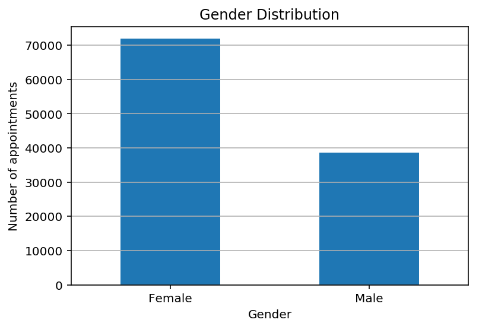

```python
# looking at the gender distribution shows that there are more females than males.
ax = gender_counts.plot(kind="bar", color=blue, rot=0);
ax.set_xticklabels(["Female", "Male"]);
ax.grid(True, axis="y")
ax.set_title("Gender Distribution")
ax.set_xlabel("Gender")
ax.set_ylabel("Number of appointments");
```

#### ScheduledDay

- the day when people arranged the appointment

```python
# convert string to a datetime format
scheduledday = df['scheduledday'].astype(np.datetime64)
scheduledday.describe()
```

```
count                  110527
unique                 103549
top       2016-05-06 07:09:54
freq                       24
first     2015-11-10 07:13:56
last      2016-06-08 20:07:23
Name: scheduledday, dtype: object
```

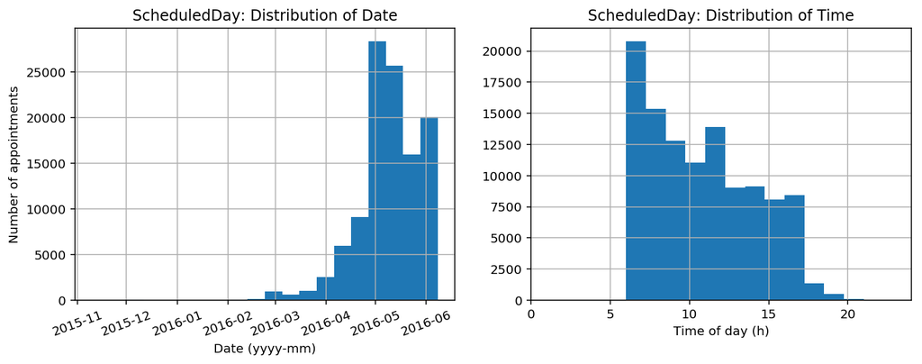

```python
# scheduled_day has date and time information
# convert string into datetime format, then make separate histograms of date and time of day

fig, (ax1, ax2) = plt.subplots(1, 2, figsize=(12,4), sharey=False)

# compute date part (without time); show distriution
scheduled_date = scheduledday.astype("datetime64[D]")
scheduled_date.hist(bins=20, ax=ax1, xrot=20, log=False);
ax1.set_title("ScheduledDay: Distribution of Date")
ax1.set_ylabel("Number of appointments")
ax1.set_xlabel("Date (yyyy-mm)")

# Compute time of day, then show istribution
scheduled_time = (scheduledday - scheduled_date).astype("timedelta64[h]")
scheduled_time.hist(bins=12, ax=ax2);
ax2.set_xlim(0, 24)
ax2.set_title("ScheduledDay: Distribution of Time")
#ax2.set_ylabel("Number of appointments")
ax2.set_xlabel("Time of day (h)");
```

- no missing values
- no obvious outliers (range of approx. 7 months)
- contains detailed time information. Time of day (when people made the appointment) ranges from 6 to 21 o'clock. This appears reasonable (office hours).

#### AppointmentDay

- the day the appointment was supposed to happen

```python
appointmentday = df['appointmentday'].astype(np.datetime64)
appointmentday.describe()
```

```
count                  110527
unique                     27
top       2016-06-06 00:00:00
freq                     4692
first     2016-04-29 00:00:00
last      2016-06-08 00:00:00
Name: appointmentday, dtype: object
```

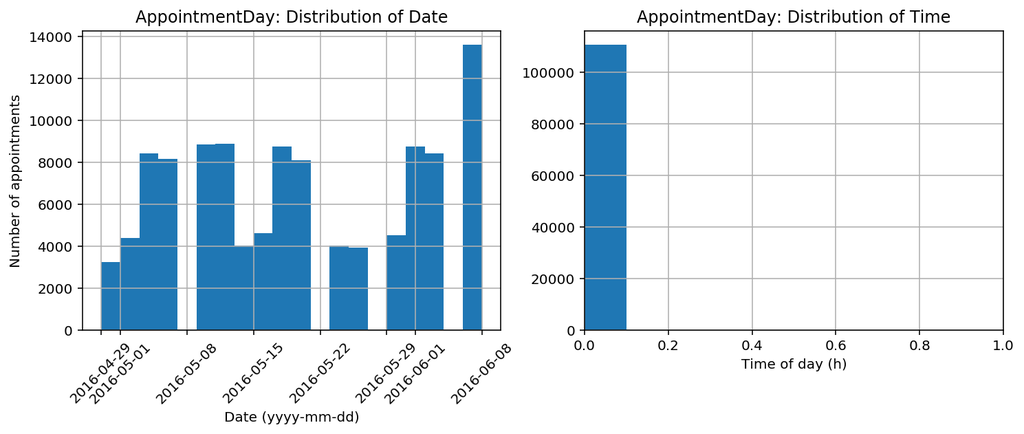

```python
# appointmentday has date and time information
# convert string into datetime format, then make separate histograms of date and time of day

fig, (ax1, ax2) = plt.subplots(1, 2, figsize=(12,4))

# distribution of appointment date
appointment_date = appointmentday.astype("datetime64[D]")
appointment_date.hist(bins=20, ax=ax1, xrot=45, log=False);
ax1.set_title("AppointmentDay: Distribution of Date")
ax1.set_ylabel("Number of appointments")
ax1.set_xlabel("Date (yyyy-mm-dd)")

# Compute time of day, then show distribution
appointment_time = (appointmentday - appointment_date).astype("timedelta64[h]")
appointment_time.hist(ax=ax2);
ax2.set_xlim(0, 1)
ax2.set_title("AppointmentDay: Distribution of Time")
#ax2.set_ylabel("Number of appointments")
ax2.set_xlabel("Time of day (h)");
```

#### Waiting time

- I introduce *waiting*, the difference (in days) between appointment day and scheduled day

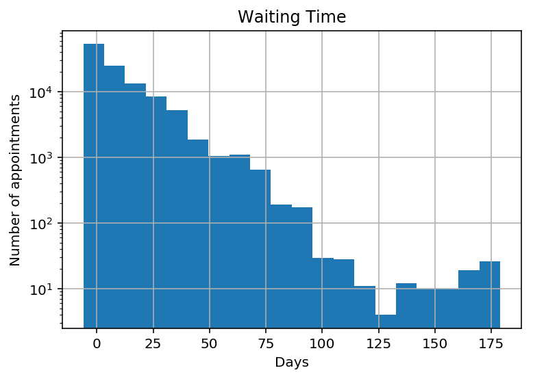

```python
df["waiting"] = (appointment_date - scheduled_date).astype("timedelta64[D]")

ax = df["waiting"].hist(bins=20, log=True);
ax.set_title("Waiting Time")
ax.set_xlabel("Days");
ax.set_ylabel("Number of appointments");
```

```python
df["waiting"].describe()
```

```
count    110527.000000
mean         10.183702
std          15.254996
min          -6.000000
25%           0.000000
50%           4.000000
75%          15.000000
max         179.000000
Name: waiting, dtype: float64
```

- maximum waiting time is 179 days (almost half a year). This is long but considered possible.
- minimum waiting time is -6 days, which makes no sense.

```python
# look at entries with waiting time < 0
df.query("waiting < 0")
```

|  | patientid | appointmentid | gender | scheduledday | appointmentday | age | neighbourhood | scholarship | hipertension | diabetes | alcoholism | handcap | sms_received | no-show | waiting |
| --- | --- | --- | --- | --- | --- | --- | --- | --- | --- | --- | --- | --- | --- | --- | --- |
| 27033 | 7839272661752 | 5679978 | M | 2016-05-10T10:51:53Z | 2016-05-09T00:00:00Z | 38 | RESISTÊNCIA | 0 | 0 | 0 | 0 | 1 | 0 | Yes | -1.0 |
| 55226 | 7896293967868 | 5715660 | F | 2016-05-18T14:50:41Z | 2016-05-17T00:00:00Z | 19 | SANTO ANTÔNIO | 0 | 0 | 0 | 0 | 1 | 0 | Yes | -1.0 |
| 64175 | 24252258389979 | 5664962 | F | 2016-05-05T13:43:58Z | 2016-05-04T00:00:00Z | 22 | CONSOLAÇÃO | 0 | 0 | 0 | 0 | 0 | 0 | Yes | -1.0 |
| 71533 | 998231581612122 | 5686628 | F | 2016-05-11T13:49:20Z | 2016-05-05T00:00:00Z | 81 | SANTO ANTÔNIO | 0 | 0 | 0 | 0 | 0 | 0 | Yes | -6.0 |
| 72362 | 3787481966821 | 5655637 | M | 2016-05-04T06:50:57Z | 2016-05-03T00:00:00Z | 7 | TABUAZEIRO | 0 | 0 | 0 | 0 | 0 | 0 | Yes | -1.0 |

```python
# keep only entries with waiting time >= 0
df = df.query("waiting >= 0")
```

#### Age

```python
# summary info on age
df["age"] = age = df["age"].astype("int")
age.describe()
```

```
count    110522.000000
mean         37.089041
std          23.110064
min          -1.000000
25%          18.000000
50%          37.000000
75%          55.000000
max         115.000000
Name: age, dtype: float64
```

*Discussion of Age*

- minimum value -1:
  - one entry
  - **Decision:** This appears to be an error. Entry will be deleted. Because it is just one entry out of > 100k, this decision will have only a minor effect of the analysis results.
- maximum value 115:
  - 5 entries.
  - 1 person with 1 appointment, another person with 4 appointments
  - this could be an error, or just very old persons.
  - next oldest patients are 102, 100
  - what evidence is for persons of age 115 in Brazil?
    - from https://gerontology.wikia.org/wiki/List_of_oldest_living_people_in_Brazil: oldest people up to 114
    - from https://www.telegraph.co.uk/news/worldnews/southamerica/brazil/10968734/Brazilian-who-turned-126-years-old-last-week-could-be-oldest-living-person.html: 126 yrs old
    - https://en.wikipedia.org/wiki/List_of_the_oldest_people_by_country: Brazil 114
    - http://www.grg.org/Adams/b.HTM: Brazil 114 (validated)
  - **Decision:** I will delete the entries with an age > 114 years because there is no validated evidence for people of this age in Brazil. Because these are just 5 out of > 100k entries, the decision will have only a minor effect of the analysis results.

```python
# how many entries are there with age < 0?
df.query('age<0')
```

|  | patientid | appointmentid | gender | scheduledday | appointmentday | age | neighbourhood | scholarship | hipertension | diabetes | alcoholism | handcap | sms_received | no-show | waiting |
| --- | --- | --- | --- | --- | --- | --- | --- | --- | --- | --- | --- | --- | --- | --- | --- |
| 99832 | 465943158731293 | 5775010 | F | 2016-06-06T08:58:13Z | 2016-06-06T00:00:00Z | -1 | ROMÃO | 0 | 0 | 0 | 0 | 0 | 0 | No | 0.0 |

```python
# how many very old patients?
df.query('age>100')
```

|  | patientid | appointmentid | gender | scheduledday | appointmentday | age | neighbourhood | scholarship | hipertension | diabetes | alcoholism | handcap | sms_received | no-show | waiting |
| --- | --- | --- | --- | --- | --- | --- | --- | --- | --- | --- | --- | --- | --- | --- | --- |
| 58014 | 976294799775439 | 5651757 | F | 2016-05-03T09:14:53Z | 2016-05-03T00:00:00Z | 102 | CONQUISTA | 0 | 0 | 0 | 0 | 0 | 0 | No | 0.0 |
| 63912 | 31963211613981 | 5700278 | F | 2016-05-16T09:17:44Z | 2016-05-19T00:00:00Z | 115 | ANDORINHAS | 0 | 0 | 0 | 0 | 1 | 0 | Yes | 3.0 |
| 63915 | 31963211613981 | 5700279 | F | 2016-05-16T09:17:44Z | 2016-05-19T00:00:00Z | 115 | ANDORINHAS | 0 | 0 | 0 | 0 | 1 | 0 | Yes | 3.0 |
| 68127 | 31963211613981 | 5562812 | F | 2016-04-08T14:29:17Z | 2016-05-16T00:00:00Z | 115 | ANDORINHAS | 0 | 0 | 0 | 0 | 1 | 0 | Yes | 38.0 |
| 76284 | 31963211613981 | 5744037 | F | 2016-05-30T09:44:51Z | 2016-05-30T00:00:00Z | 115 | ANDORINHAS | 0 | 0 | 0 | 0 | 1 | 0 | No | 0.0 |
| 90372 | 234283596548 | 5751563 | F | 2016-05-31T10:19:49Z | 2016-06-02T00:00:00Z | 102 | MARIA ORTIZ | 0 | 0 | 0 | 0 | 0 | 0 | No | 2.0 |
| 97666 | 748234579244724 | 5717451 | F | 2016-05-19T07:57:56Z | 2016-06-03T00:00:00Z | 115 | SÃO JOSÉ | 0 | 1 | 0 | 0 | 0 | 1 | No | 15.0 |

```python
df = df.query("(age >= 0) & (age < 115)")
```

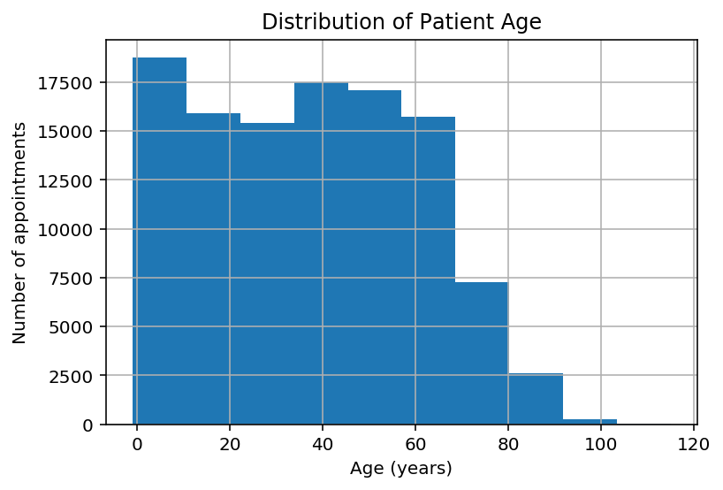

```python
ax = age.hist();
ax.set_title("Distribution of Patient Age")
ax.set_ylabel("Number of appointments")
ax.set_xlabel("Age (years)");
```

#### Neighbourhood, Scholarship, Hipertension, Diabetes, Alcoholism, Handcap

- not used in analysis, therefore not investigated in detail
- columns will be dropped later

#### SMS

- two values (1, 0)
- no missing values
- will import this as integer

```python
sms = df["sms_received"]
print(sms.value_counts())
```

```
0    75035
1    35481
Name: sms_received, dtype: int64
```

```python
df["sms_received"] = df["sms_received"].astype(int)
```

#### No-show

- 2 unique values: "No" and "Yes"
- no missing values
- will import this as integer: "No" -> 0, "Yes": 1

```python
df["no-show"].value_counts()
```

```
No     88205
Yes    22311
Name: no-show, dtype: int64
```

```python
# function to concert yes/no values into integers
def yesno2int(s):
    """Return 1 if string is 'Yes', 0 if string is 'No'."""
    if s == "Yes":
        return 1
    elif s == "No":
        return 0

# apply function
df["no-show"] = df["no-show"].apply(yesno2int)
```

#### Final dataset

- dropping all columns not required for analysis.

```python
# because I will not further exploit individual patients, I can drop the PatientId column
# AppointmentID can also be dropped, not used further.
df.drop(columns=["patientid", "appointmentid", "gender", "appointmentday",
                 "scheduledday", "neighbourhood", "scholarship", "hipertension",
                 "diabetes", "alcoholism", "handcap",
                ], inplace=True, errors='ignore')
```

```python
df.head()
```

|  | age | sms_received | no-show | waiting |
| --- | --- | --- | --- | --- |
| 0 | 62 | 0 | 0 | 0.0 |
| 1 | 56 | 0 | 0 | 0.0 |
| 2 | 62 | 0 | 0 | 0.0 |
| 3 | 8 | 0 | 0 | 0.0 |
| 4 | 56 | 0 | 0 | 0.0 |

```python
df.describe()
```

|  | age | sms_received | no-show | waiting |
| --- | --- | --- | --- | --- |
| count | 110516.000000 | 110516.000000 | 110516.000000 | 110516.000000 |
| mean | 37.085861 | 0.321049 | 0.201880 | 10.184272 |
| std | 23.104465 | 0.466882 | 0.401405 | 15.255201 |
| min | 0.000000 | 0.000000 | 0.000000 | 0.000000 |
| 25% | 18.000000 | 0.000000 | 0.000000 | 0.000000 |
| 50% | 37.000000 | 0.000000 | 0.000000 | 4.000000 |
| 75% | 55.000000 | 1.000000 | 0.000000 | 15.000000 |
| max | 102.000000 | 1.000000 | 1.000000 | 179.000000 |

## Exploratory Data Analysis

### 1. How does age influence the no-show rate?

- *No-show rate* is defined as the number of appointments where no-show == 1 divided by all appointments.
- For the complete cleaned dataset, consisting of 110516 entries, the no-show rate is 0.202.
- Age is not uniformly distributed.
- To investigate the influence of age, I divide the dataset into equally sized bins.

```python
df['no-show'].describe()
```

```
count    110516.000000
mean          0.201880
std           0.401405
min           0.000000
25%           0.000000
50%           0.000000
75%           0.000000
max           1.000000
Name: no-show, dtype: float64
```

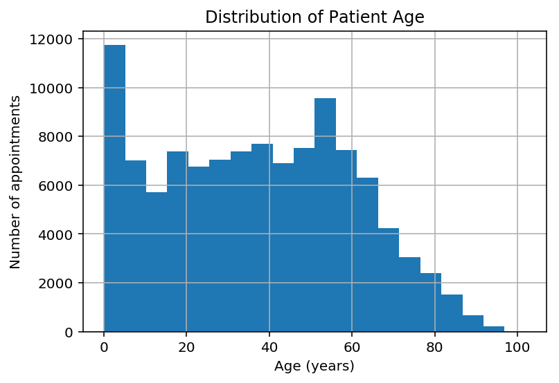

```python
ax = df["age"].hist(bins=20);
ax.set_title("Distribution of Patient Age")
ax.set_ylabel("Number of appointments")
ax.set_xlabel("Age (years)");
```

```python
# make 10 equal sized groups
age_cat, age_bins = pd.qcut(df["age"], 10, retbins=True)
```

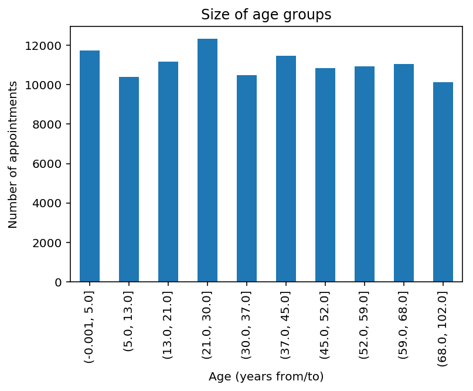

```python
# verify that bins are more or less equally sized
ax = df['age'].groupby(age_cat).count().plot(kind='bar', color=blue);
ax.set_title("Size of age groups")
ax.set_ylabel("Number of appointments")
ax.set_xlabel("Age (years from/to)");
```

#### Visualize the no-show rate

```python
# no show rate, by age group
nsr = df['no-show'].groupby(age_cat).mean()
nsr
```

```
age
(-0.001, 5.0]    0.186259
(5.0, 13.0]      0.232920
(13.0, 21.0]     0.254480
(21.0, 30.0]     0.246391
(30.0, 37.0]     0.216595
(37.0, 45.0]     0.211022
(45.0, 52.0]     0.183732
(52.0, 59.0]     0.174179
(59.0, 68.0]     0.151394
(68.0, 102.0]    0.154697
Name: no-show, dtype: float64
```

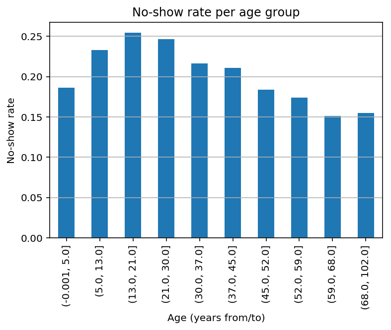

```python
ax = nsr.plot.bar(color=blue);
ax.grid(axis="y")
ax.set_title("No-show rate per age group")
ax.set_ylabel("No-show rate")
ax.set_xlabel("Age (years from/to)");
```

**Further investigation**

- Find out if this is pure chance or if there is statistical evidence behind it.
- I perform an investigation for one group (the one with the highest no-show rate).
- This group has a no-show rate of 0.254 (compared to the overall mean of 0.202)

I use the central limit theorem for investigation.

```python
# pick one group: 14 to 21 year olds
df2 = df.query("age > 13 & age <= 21")
df2["no-show"].describe()
```

```
count    11160.000000
mean         0.254480
std          0.435588
min          0.000000
25%          0.000000
50%          0.000000
75%          1.000000
max          1.000000
Name: no-show, dtype: float64
```

```python
def sample_no_show(df, sample_size, n):
    """Take n samples of size sample_size from the 'no-show' column of dataframe df,
    compute the mean of each sample, and return the means as a pandas Series."""
    means = list()
    for i in range(n):
        means.append(df["no-show"].sample(sample_size).mean())
    return pd.Series(means)
```

```python
sample_size = 100 # reasonably large value
n = 10000         # ideally, we use all possible samples

mu = df["no-show"].mean()
print("population mean: %.3f" % mu)
se = df["no-show"].std()/np.sqrt(sample_size)
print("standard error for sample size %i: %.3f" %(sample_size, se))
```

```
population mean: 0.202
standard error for sample size 100: 0.040
```

```python
s2 = sample_no_show(df2, sample_size, n)
s2.describe()
```

```
count    10000.000000
mean         0.254303
std          0.043315
min          0.110000
25%          0.220000
50%          0.250000
75%          0.280000
max          0.420000
dtype: float64
```

```python
z = (s2.mean() - mu) / se
print(z)
```

```
1.305980523982553
```

```python
# what's the proba?
from scipy.stats import norm

# proba of drawing a sample of size 100 with mean 0.254
1 - norm.cdf(z)
```

```
0.09577959041422535
```

That's about 10% probability - quite low.

It means that it's not very probable to draw a sample of size 100 out of all appointments that has a mean no-show rate of 25.4% or more.

### 2. Does waiting time have an influence?

```python
nsr_wait = df.groupby("waiting", as_index=True)["no-show"].agg(["mean", "count"])
```

```python
nsr_wait.head()
```

| waiting | mean | count |
| --- | --- | --- |
| 0.0 | 0.046472 | 38561 |
| 1.0 | 0.213505 | 5213 |
| 2.0 | 0.238216 | 6725 |
| 3.0 | 0.234735 | 2735 |
| 4.0 | 0.232703 | 5290 |

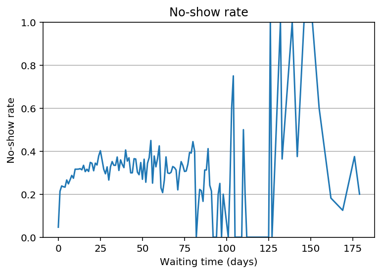

```python
ax = nsr_wait["mean"].plot(kind="line");

ax.grid(True, axis="y");
ax.set_ylabel("No-show rate");
ax.set_xlabel("Waiting time (days)");
ax.set_title("No-show rate");
ax.set_ylim(0,1);
```

for zero waiting time (appointment on same day) no-show rate is 4.6% 1 day waiting: about 20% after that increasing (with waiting time) to about 40% starting from waiting time of about 50 days: high fluctuations. This is because bin size is 1 day, and there are few data in each bin.

Therefore: make less (more or less equal-sized) bins

```python
cat_w, bins_w = pd.qcut(df.waiting, 12, retbins=True, duplicates="drop", )
print(bins_w)
df.groupby(cat_w)["no-show"].agg(["mean", "count"])
```

```
[  0.   2.   4.   6.   9.  15.  22.  32. 179.]
```

| waiting | mean | count |
| --- | --- | --- |
| (-0.001, 2.0] | 0.089249 | 50499 |
| (2.0, 4.0] | 0.233396 | 8025 |
| (4.0, 6.0] | 0.256084 | 7314 |
| (6.0, 9.0] | 0.273550 | 8843 |
| (9.0, 15.0] | 0.318665 | 9590 |
| (15.0, 22.0] | 0.323385 | 8544 |
| (22.0, 32.0] | 0.328828 | 8582 |
| (32.0, 179.0] | 0.328764 | 9119 |

```python
bins_w = [-0.01, 0, 1, 2, 3, 4, 6, 9, 15, 22, 32, 179]
cat_w = pd.cut(df.waiting, bins_w)

nsr_wait = df.groupby(cat_w)["no-show"].agg(["mean", "count"])
#nsr_wait
```

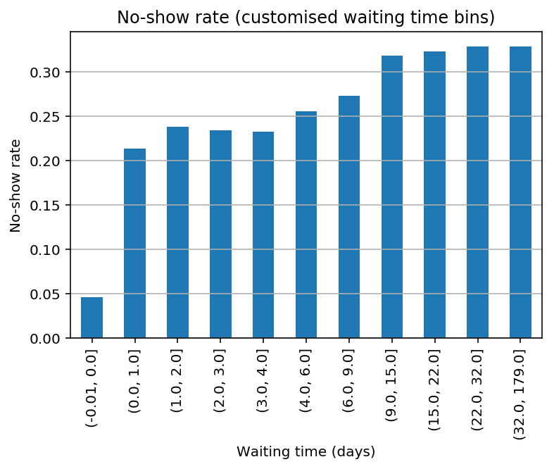

```python
ax = nsr_wait["mean"].plot(kind='bar', color=blue)
ax.grid(True, axis="y");
ax.set_ylabel("No-show rate");
ax.set_xlabel("Waiting time (days)");
ax.set_title("No-show rate (customised waiting time bins)");
```

there is a clear trend that no-show rate increases with waiting time.

- for appointment on the same day (waiting time = 0), no-show rate is 4.6%
- for waiting time between 1 and 9 days, no-show rate is between 20 and 30%
- for waiting time of 10 days and more, the no show rate is approximately 33%

### 3. Do SMS have an influence?

```python
print(df['no-show'].mean())
print(df.sms_received.mean())

nsr_sms = df.groupby("sms_received")['no-show'].agg(["mean", "count"])
nsr_sms
```

```
0.20188027073003004
0.32104853595859423
```

| sms_received | mean | count |
| --- | --- | --- |
| 0 | 0.166949 | 75035 |
| 1 | 0.275753 | 35481 |

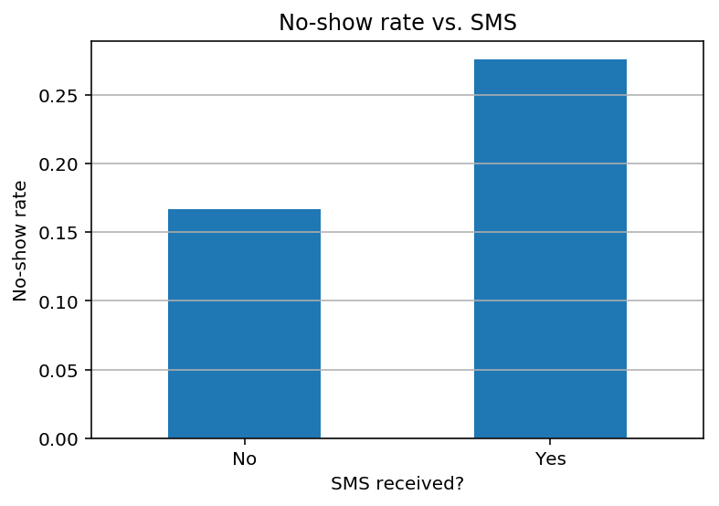

```python
ax = nsr_sms['mean'].plot(kind='bar', color=blue, rot=0);
ax.grid(axis="y")
ax.set_title("No-show rate vs. SMS")
ax.set_ylabel("No-show rate")
ax.set_xlabel("SMS received?");
ax.set_xticklabels(["No", "Yes"]);
```

- about 32% of all appointments receive an sms
- overall nsr is 20.2%
- what's unexpected here: people who have received an sms have a higher no-show rate.

### 4. Combined effect of waiting time and SMS

```python
df.groupby([cat_w, "sms_received"])["no-show"].describe()
```

| waiting | sms_received | count | mean | std | min | 25% | 50% | 75% | max |
| --- | --- | --- | --- | --- | --- | --- | --- | --- | --- |
| (-0.01, 0.0] | 0 | 38561.0 | 0.046472 | 0.210507 | 0.0 | 0.0 | 0.0 | 0.0 | 1.0 |
| (0.0, 1.0] | 0 | 5213.0 | 0.213505 | 0.409820 | 0.0 | 0.0 | 0.0 | 0.0 | 1.0 |
| (1.0, 2.0] | 0 | 6725.0 | 0.238216 | 0.426023 | 0.0 | 0.0 | 0.0 | 0.0 | 1.0 |
| (2.0, 3.0] | 0 | 1829.0 | 0.245489 | 0.430495 | 0.0 | 0.0 | 0.0 | 0.0 | 1.0 |
|  | 1 | 906.0 | 0.213024 | 0.409671 | 0.0 | 0.0 | 0.0 | 0.0 | 1.0 |
| (3.0, 4.0] | 0 | 2236.0 | 0.243739 | 0.429433 | 0.0 | 0.0 | 0.0 | 0.0 | 1.0 |
|  | 1 | 3054.0 | 0.224623 | 0.417402 | 0.0 | 0.0 | 0.0 | 0.0 | 1.0 |
| (4.0, 6.0] | 0 | 2576.0 | 0.289208 | 0.453483 | 0.0 | 0.0 | 0.0 | 1.0 | 1.0 |
|  | 1 | 4738.0 | 0.238075 | 0.425950 | 0.0 | 0.0 | 0.0 | 0.0 | 1.0 |
| (6.0, 9.0] | 0 | 3556.0 | 0.284308 | 0.451148 | 0.0 | 0.0 | 0.0 | 1.0 | 1.0 |
|  | 1 | 5287.0 | 0.266314 | 0.442072 | 0.0 | 0.0 | 0.0 | 1.0 | 1.0 |
| (9.0, 15.0] | 0 | 4101.0 | 0.358937 | 0.479747 | 0.0 | 0.0 | 0.0 | 1.0 | 1.0 |
|  | 1 | 5489.0 | 0.288577 | 0.453142 | 0.0 | 0.0 | 0.0 | 1.0 | 1.0 |
| (15.0, 22.0] | 0 | 3538.0 | 0.362069 | 0.480667 | 0.0 | 0.0 | 0.0 | 1.0 | 1.0 |
|  | 1 | 5006.0 | 0.296045 | 0.456557 | 0.0 | 0.0 | 0.0 | 1.0 | 1.0 |
| (22.0, 32.0] | 0 | 3354.0 | 0.374776 | 0.484137 | 0.0 | 0.0 | 0.0 | 1.0 | 1.0 |
|  | 1 | 5228.0 | 0.299350 | 0.458017 | 0.0 | 0.0 | 0.0 | 1.0 | 1.0 |
| (32.0, 179.0] | 0 | 3346.0 | 0.376569 | 0.484598 | 0.0 | 0.0 | 0.0 | 1.0 | 1.0 |
|  | 1 | 5773.0 | 0.301057 | 0.458757 | 0.0 | 0.0 | 0.0 | 1.0 | 1.0 |

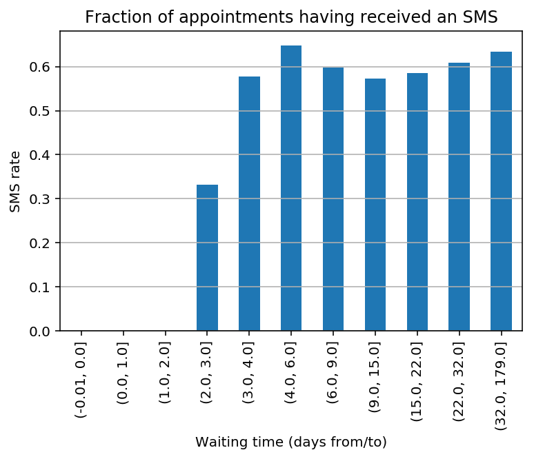

```python
ax = df.groupby(cat_w)["sms_received"].mean().plot(kind='bar', color=blue)
ax.grid(True, axis="y");
ax.set_title("Fraction of appointments having received an SMS");
ax.set_xlabel("Waiting time (days from/to)");
ax.set_ylabel("SMS rate");
```

**Observations:**

- appointments with waiting time 0 to 2 days did not get SMS
- starting from 3 days waiting time, people get an SMS
  - about 1/3 of appointments with waiting time 3 days receive an sms
  - about 60% of appointments with waiting time > 3 days receive an sms

**Next step:**

A high fraction of appointments has a waiting time less than 3 days. For these appointments, so SMS is sent. In order to investigate the influence of SMS on no-show rate, I will look in detail at appointments with a waiting time of at least 3 days.

```python
df3 = df.query("waiting >= 3")

bins_w3 = [2.99, 3, 4, 6, 9, 15, 22, 32, 179]
cat_w3 = pd.cut(df3.waiting, bins_w3)
```

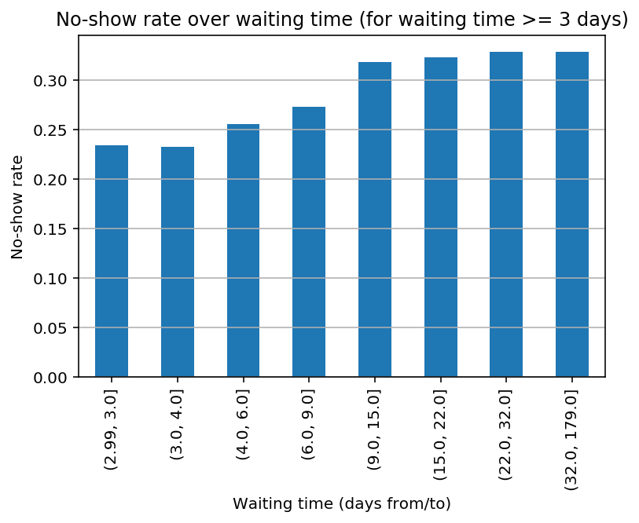

```python
# overall no-show rate, waiting >= 3
ax = df3.groupby(cat_w3)["no-show"].mean().plot(kind="bar", color=blue);
ax.grid(True, axis="y");
ax.set_title("No-show rate over waiting time (for waiting time >= 3 days)");
ax.set_xlabel("Waiting time (days from/to)");
ax.set_ylabel("No-show rate");
```

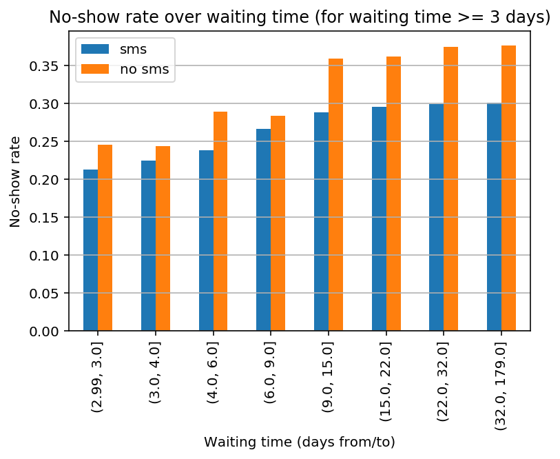

```python
# no-show rate, waiting >= 3, split by SMS yes or no
wait_sms = df3.groupby([cat_w3, "sms_received"], as_index=False)["no-show"].mean()
sms = wait_sms.query("sms_received == 1")["no-show"]
nosms = wait_sms.query("sms_received == 0")["no-show"]

dfx = pd.DataFrame({"waiting": cat_w3.cat.categories.values, "sms": sms.values, "no sms": nosms.values})
ax = dfx.plot(x='waiting', kind='bar', rot=90);

ax.grid(True, axis="y");
ax.set_title("No-show rate over waiting time (for waiting time >= 3 days)");
ax.set_xlabel("Waiting time (days from/to)");
ax.set_ylabel("No-show rate");
```

## Conclusions

This analysis investigated the influence of age, waiting time, and SMS on the rate of no-show appointments.

The overall no-show rate is 20%.